# Practical machine Learning

BaronBlaxland

26 July 2015

First of all the training data was read in and from that it was split into two sets train (70%) and test (30%). The data was examined and there were many NA and irrelevant data therefore these datasets were removed.

```r
library(caret)
set.seed(12345)
pml.training <- read.csv("C:/Users/Lizzie/Desktop/coursera/pml-training.csv", header=TRUE);

inTrain<-createDataPartition(y=pml.training$classe, p=0.7,list=FALSE);

training<-pml.training[inTrain,];
testing<-pml.training[-inTrain,];

new.training<-training[ , colSums(is.na(training)) == 0];
numeric.training<- sapply(new.training, is.numeric);
new.new<-new.training[,numeric.training];

new.new<-cbind(new.new,training$classe);
```

This data set was then checked to ensure there were no zero variance and as these values were found to all be false this emant all the variables were suitable to include in the future analysis.

```r
check.zero.variance <- nearZeroVar(new.new, saveMetrics=TRUE)
check.zero.variance
```

```
##                      freqRatio percentUnique zeroVar   nzv
## X                     1.000000  100.00000000   FALSE FALSE
## raw_timestamp_part_1  1.000000    6.08575380   FALSE FALSE
## raw_timestamp_part_2  1.000000   89.75030938   FALSE FALSE
## num_window            1.000000    6.23862561   FALSE FALSE
## roll_belt             1.080123    8.13132416   FALSE FALSE
## pitch_belt            1.006849   12.17150761   FALSE FALSE
## yaw_belt              1.022161   12.92130742   FALSE FALSE
## total_accel_belt      1.054462    0.19654946   FALSE FALSE
## gyros_belt_x          1.033024    0.96090850   FALSE FALSE
## gyros_belt_y          1.129367    0.48773386   FALSE FALSE
## gyros_belt_z          1.085784    1.18657640   FALSE FALSE
## accel_belt_x          1.061338    1.15017835   FALSE FALSE
## accel_belt_y          1.117151    0.99730654   FALSE FALSE
## accel_belt_z          1.103110    2.13292568   FALSE FALSE
## magnet_belt_x         1.069231    2.18388294   FALSE FALSE
## magnet_belt_y         1.123894    2.08196841   FALSE FALSE
## magnet_belt_z         1.024845    3.18118949   FALSE FALSE
## roll_arm             55.488372   17.76224794   FALSE FALSE
## pitch_arm            91.807692   20.13540074   FALSE FALSE
## yaw_arm              33.138889   19.29096600   FALSE FALSE
## total_accel_arm       1.032206    0.47317464   FALSE FALSE
## gyros_arm_x           1.008065    4.58615418   FALSE FALSE
## gyros_arm_y           1.470588    2.66433719   FALSE FALSE
## gyros_arm_z           1.203390    1.70342870   FALSE FALSE
## accel_arm_x           1.008547    5.57618112   FALSE FALSE
## accel_arm_y           1.163265    3.77083788   FALSE FALSE
## accel_arm_z           1.030612    5.58346073   FALSE FALSE
## magnet_arm_x          1.016129    9.55812768   FALSE FALSE
## magnet_arm_y          1.063492    6.23134600   FALSE FALSE
## magnet_arm_z          1.061728    9.13591032   FALSE FALSE
## roll_dumbbell         1.155556   87.00589648   FALSE FALSE
## pitch_dumbbell        2.048077   84.92392808   FALSE FALSE
## yaw_dumbbell          1.155556   86.36529082   FALSE FALSE
## total_accel_dumbbell  1.080559    0.31302322   FALSE FALSE
## gyros_dumbbell_x      1.004684    1.70342870   FALSE FALSE
## gyros_dumbbell_y      1.207229    1.94365582   FALSE FALSE
## gyros_dumbbell_z      1.061576    1.42680352   FALSE FALSE
## accel_dumbbell_x      1.030043    2.98464002   FALSE FALSE
## accel_dumbbell_y      1.023121    3.28310403   FALSE FALSE
## accel_dumbbell_z      1.126582    2.91912353   FALSE FALSE
## magnet_dumbbell_x     1.181818    7.84741938   FALSE FALSE
## magnet_dumbbell_y     1.333333    5.98383927   FALSE FALSE
## magnet_dumbbell_z     1.084034    4.78998326   FALSE FALSE
## roll_forearm         12.013100   13.59831113   FALSE FALSE
## pitch_forearm        62.477273   18.83235059   FALSE FALSE
## yaw_forearm          15.531073   12.88490937   FALSE FALSE
## total_accel_forearm   1.146991    0.50229308   FALSE FALSE
## gyros_forearm_x       1.016173    2.02373153   FALSE FALSE
## gyros_forearm_y       1.034483    5.24131907   FALSE FALSE
## gyros_forearm_z       1.154762    2.15476450   FALSE FALSE
## accel_forearm_x       1.111111    5.67081604   FALSE FALSE
## accel_forearm_y       1.029412    7.11945840   FALSE FALSE
## accel_forearm_z       1.009174    4.08386111   FALSE FALSE
## magnet_forearm_x      1.075472   10.50447696   FALSE FALSE
## magnet_forearm_y      1.000000   13.27800830   FALSE FALSE
## magnet_forearm_z      1.095238   11.71289219   FALSE FALSE
## training$classe       1.469526    0.03639805   FALSE FALSE
```

Next some pre-processing techniques were used to determine the principle components of the data with five groupings of data.

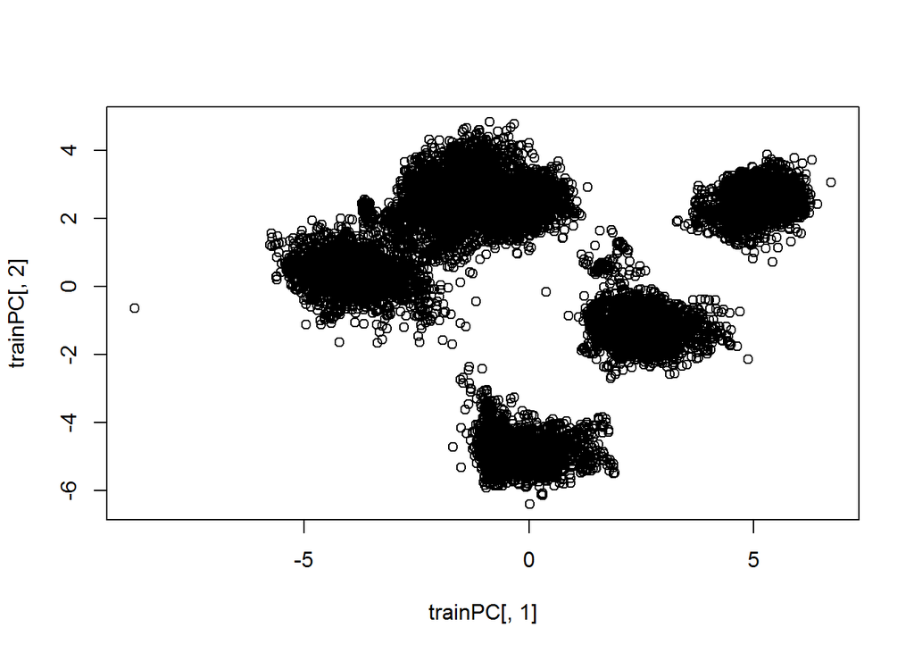

```r
preProc<-preProcess(new.new[-57],method="pca",pcaComp=5)
trainPC<-predict(preProc,new.new[-57])
plot(trainPC[,1],trainPC[,2])
```

```r
new.testing<-training[ , colSums(is.na(testing)) == 0]
numeric.testing<- sapply(new.testing, is.numeric)
new.test<-new.training[,numeric.testing]

new.test<-cbind(new.new,training$classe)
new.test<-new.test[,-58]

preProc.test<-preProcess(new.test[,-57],method="pca",pcaComp=5)
trainPC.test<-predict(preProc,new.test[-57])


modelFit<-train(new.new$"training$classe"~.,method="knn",preProcess=c("center", "scale"), trControl=trainControl(method = "cv", number = 5),data=trainPC)

modelFit
```

[output not shown]

```r
predictions <- predict(modelFit, newdata=new.test$classe)

print(confusionMatrix(predictions, new.test$"training$classe"))
```

```
## Confusion Matrix and Statistics
##
##           Reference
## Prediction    A    B    C    D    E
##          A 3621  120   57   38   47
##          B   59 2284   82   30   75
##          C  110  124 2131  103   58
##          D   83   68  100 2050   75
##          E   33   62   26   31 2270
##
## Overall Statistics
##
##                Accuracy : 0.8995
##                  95% CI : (0.8943, 0.9044)
##     No Information Rate : 0.2843
##     P-Value [Acc > NIR] : < 2.2e-16
##
##                   Kappa : 0.8729
##  Mcnemar's Test P-Value : < 2.2e-16
##
## Statistics by Class:
##
##                      Class: A Class: B Class: C Class: D Class: E
## Sensitivity            0.9270   0.8593   0.8894   0.9103   0.8990
## Specificity            0.9733   0.9778   0.9652   0.9716   0.9864
## Pos Pred Value         0.9325   0.9028   0.8436   0.8628   0.9372
## Neg Pred Value         0.9711   0.9666   0.9764   0.9822   0.9775
## Prevalence             0.2843   0.1935   0.1744   0.1639   0.1838
## Detection Rate         0.2636   0.1663   0.1551   0.1492   0.1652
## Detection Prevalence   0.2827   0.1842   0.1839   0.1730   0.1763
## Balanced Accuracy      0.9502   0.9185   0.9273   0.9410   0.9427
```

With an accuracy of 90% this seemed like an accurate method. This was then used on the real data, however, when the data was input the wrong results were found. Therefore a new method was used.

[output not shown]

The new method using random trees was then utilised with a centre and scale method of pre processing and a four fold cross validation.

```r
pml.training <- read.csv("C:/Users/Lizzie/Desktop/coursera/pml-training.csv", header=TRUE);

set.seed(12345)

inTrain<-createDataPartition(y=pml.training$classe, p=0.7,list=FALSE);

training<-pml.training[inTrain,];
testing<-pml.training[-inTrain,];

new.training<-training[ , colSums(is.na(training)) == 0];
numeric.training<- sapply(new.training, is.numeric);
new.new<-new.training[,numeric.training];

new.new<-cbind(new.new,training$classe);

new.new<-new.new[,-1]
new.new<-new.new[,-1]
new.new<-new.new[,-1]
new.new<-new.new[,-1]
new.new<-new.new[,-1]


modelFit <- train(new.new$"training$classe" ~ ., method="rf",preProcess=c("center", "scale"), trControl=trainControl(method = "cv", number = 4), data=new.new[-52])
print(modelFit, digits=3)
```

```
## Random Forest
##
## 13737 samples
##    50 predictor
##     5 classes: 'A', 'B', 'C', 'D', 'E'
##
## Pre-processing: centered, scaled
## Resampling: Cross-Validated (4 fold)
## Summary of sample sizes: 10301, 10304, 10303, 10303
## Resampling results across tuning parameters:
##
##   mtry  Accuracy  Kappa  Accuracy SD  Kappa SD
##    2    0.989     0.986  0.00269      0.00341
##   26    0.990     0.987  0.00355      0.00450
##   51    0.987     0.984  0.00428      0.00541
##
## Accuracy was used to select the optimal model using  the largest value.
## The final value used for the model was mtry = 26.
```

```r
pml.testing <- read.csv("C:/Users/Lizzie/Desktop/coursera/pml-testing.csv", header=TRUE)

final.testing<-pml.testing[ , colSums(is.na(pml.testing)) == 0]

 final.numeric.testing<- sapply(final.testing, is.numeric)
 final.test<-final.testing[,final.numeric.testing]

 final.test<-final.test[,-1]
 final.test<-final.test[,-1]
 final.test<-final.test[,-1]
 final.test<-final.test[,-1]
 final.test<-final.test[,-1]
 print(predict(modelFit, newdata=final.test))
```

```
##  [1] B A B A A E D B A A B C B A E E A B B B
## Levels: A B C D E
```